# Econ 3110: Problem Set 9

## Question 1: Cournot Competition (General Derivations)

**Setup:**

- Inverse Demand: $P = a - bQ$, where $Q = \sum q_i$.
- Cost Structure: Constant marginal cost $c_i$ for firm $i$ (no fixed costs).

### (a) Duopoly Case ($n=2$)

Firm $i$ seeks to maximize profit $\pi_i = (P - c_i)q_i = (a - b(q_i + q_j) - c_i)q_i$.
The First Order Condition (FOC) with respect to $q_i$ yields the reaction function: $$ \frac{\partial \pi_i}{\partial q_i} = a - bq_j - 2bq_i - c_i = 0 \implies q_i = \frac{a - c_i - bq_j}{2b} $$

Solving the system of reaction functions simultaneously for firms 1 and 2:

1. $2bq_1 + bq_2 = a - c_1$
2. $bq_1 + 2bq_2 = a - c_2$

Multiplying (1) by 2 and subtracting (2) allows us to isolate $q_1$: $$ 3bq_1 = a - 2c_1 + c_2 \implies q_1^* = \frac{a - 2c_1 + c_2}{3b} $$ By symmetry, $q_2^* = \frac{a - 2c_2 + c_1}{3b}$.

**Equilibrium Price:** $$ Q = q_1 + q_2 = \frac{2a - c_1 - c_2}{3b} \implies P^* = a - b\left(\frac{2a - c_1 - c_2}{3b}\right) = \frac{a + c_1 + c_2}{3} $$

### (b) Generalization to $n > 2$ Firms

The FOC for any firm $i$ is $a - bQ - bq_i - c_i = 0$ (noting that $\frac{dQ}{dq_i}=1$). Rearranging for $q_i$ gives $q_i = \frac{P - c_i}{b}$.
Summing this expression over all $n$ firms: $$ Q = \sum_{i=1}^n \frac{P - c_i}{b} = \frac{nP - \sum c_i}{b} $$ Substituting the demand curve $P = a - bQ$ into the summation: $$ bQ = n(a - bQ) - \sum c_i \implies bQ(1+n) = na - \sum c_i $$ Thus, total output and price are: $$ Q^* = \frac{na - \sum_{i=1}^n c_i}{b(n+1)} \quad \text{and} \quad P^* = \frac{a + \sum_{i=1}^n c_i}{n+1} $$

### (c) Condition for Viability

For a firm to produce a positive quantity ($q_i > 0$), price must exceed its marginal cost ($P^* > c_i$). Substituting our expression for $P^*$: $$ \frac{a + \sum_{j=1}^n c_j}{n+1} > c_i \implies a + \sum_{j \neq i} c_j > n c_i $$ **Interpretation:** For firm $i$ to remain active in the market, its marginal cost cannot be excessively high relative to the "average" efficiency of the market. Specifically, the sum of the market size parameter $a$ and its rivals' costs must exceed $n$ times its own cost. If a firm is significantly inefficient compared to competitors, it will be priced out of the equilibrium.

### (d) Cost Shock Transmission

If every firm's cost increases by $\epsilon$, the new aggregate cost term becomes $\sum c_i + n\epsilon$. $$ P_{new} = \frac{a + \sum c_i + n\epsilon}{n+1} = P_{old} + \frac{n}{n+1}\epsilon $$ **Intuition:** The equilibrium price rises by **less than** $\epsilon$ (incomplete pass-through). Because the demand curve is downward-sloping, firms face a trade-off: passing on the full cost would reduce quantity demanded so drastically that profits would plummet. Consequently, the burden of the cost shock is shared; firms absorb a portion of the cost increase ($1 - \frac{n}{n+1}$), while consumers pay the remainder.

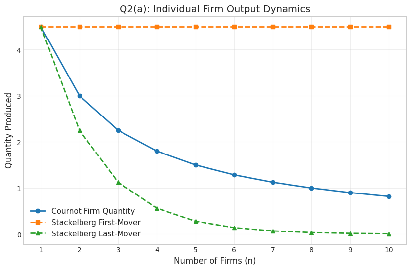

### Interpretation of Q2(a)

The figure elucidates the distinct strategic incentives between the two market structures. In the **Stackelberg** framework, the first-mover enjoys a distinct advantage by committing to a high output level (essentially the monopoly quantity adjusted for reaction), forcing subsequent firms to accept residual demand. This results in the first-mover's quantity remaining robust regardless of $n$, while the last-mover's output decays geometrically toward zero.

In contrast, **Cournot** competition is symmetric; no firm possesses a strategic commitment capability. As $n$ increases, the "external effect" of competition forces every firm to reduce individual output harmoniously, converging toward zero more gradually than the last Stackelberg mover.

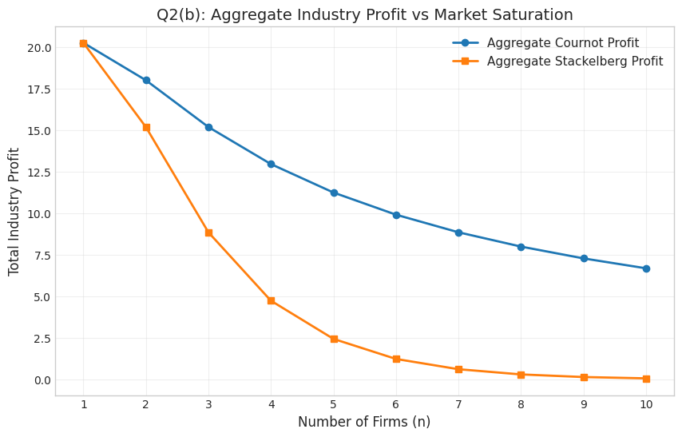

### Interpretation of Q2(b)

If the objective is to maximize aggregate industry profits, **Cournot competition** is the superior structure. The intuition is that the sequential nature of Stackelberg competition exacerbates the dissipation of rents. The first-mover's aggressive quantity commitment, combined with the subsequent entry of followers, results in a higher total industry output ($Q$) compared to the symmetric Cournot outcome. This higher aggregate output drives the market price closer to marginal cost, thereby lowering the total surplus available to the producers.

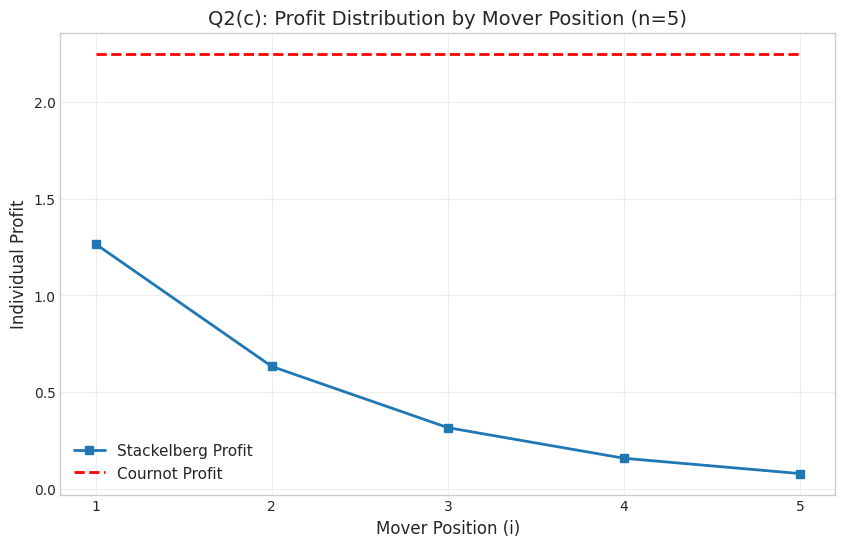

### Interpretation of Q2(c)

This figure illustrates a "Pyrrhic victory" for the first-mover. While Firm 1 maintains a significant relative advantage over the later movers (Firm 1 profits > Firm 2 profits), it actually earns **less** than the symmetric Cournot benchmark. With $n=5$, the aggressive output expansion required to preempt rivals depresses the market price so severely that the volume effect cannot compensate for the price effect. Consequently, **all firms**, including the leader, would strictly prefer the simultaneous Cournot game to this sequential equilibrium.

## Question 3: Collusion and Infinite Horizons

**Setup:** Symmetric costs $c$, Infinite horizon with discount factor $\delta$.

### (a) The Collusive Benchmark ($\pi_C$)

Under perfect collusion, firms act as a single monopolist maximizing $\Pi = (a - bQ - c)Q$.
The monopoly quantity is $Q^* = \frac{a-c}{2b}$.
Total monopoly profit is $\frac{(a-c)^2}{4b}$.
Since this is shared equally among $n$ firms: $$ \pi_C = \frac{(a-c)^2}{4nb} $$

### (b) The Temptation to Defect ($\pi_D$)

If rivals produce their share of the cartel output, $Q_{-i} = (n-1)\frac{a-c}{2nb}$.
Firm $i$ maximizes against this fixed output. The residual demand intercept is $A = a - b Q_{-i} = a - \frac{n-1}{2n}(a-c)$. Firm $i$'s best response is $\tilde{q}_i = \frac{A-c}{2b}$. Algebraically simplifying yields: $$ \tilde{q}_i = \frac{a-c}{2b} \left( \frac{n+1}{2n} \right) $$ The resulting deviation profit is: $$ \pi_D = \frac{(a-c)^2}{4b} \left( \frac{n+1}{2n} \right)^2 $$

### (c) The Punishment: Cournot ($\pi_G$)

From our earlier work in Q1(b), the symmetric Cournot profit is: $$ \pi_G = \frac{(a-c)^2}{b(n+1)^2} $$

### (d) Credibility of Grim Trigger

Cournot competition serves as a suitable punishment because it constitutes a **Nash Equilibrium** of the stage game. Unlike a threat to set price to zero (which would hurt the punisher), reverting to Cournot is incentive-compatible; once the punishment phase begins, no firm has an incentive to deviate from the punishment strategy. This makes the threat **Subgame Perfect**.

### (e) Valuation of Strategies

- **Value of Sustained Collusion:** Sum of a geometric series. $$ V_C = \sum_{t=0}^{\infty} \delta^t \pi_C = \frac{\pi_C}{1-\delta} $$
- **Value of Deviation:** One period of high profit $\pi_D$, followed by $\pi_G$ forever. $$ V_D = \pi_D + \frac{\delta \pi_G}{1-\delta} $$

### (f) The Critical Discount Factor

Collusion is sustainable if $V_C \ge V_D$. Rearranging the inequality: $$ \frac{\pi_C}{1-\delta} \ge \pi_D + \frac{\delta \pi_G}{1-\delta} \implies \delta (\pi_D - \pi_G) \ge \pi_D - \pi_C $$ $$ \delta \ge \frac{\pi_D - \pi_C}{\pi_D - \pi_G} $$ **Intuition:** The numerator represents the immediate "temptation" (short-term gain), while the denominator represents the "punishment severity" (long-term loss). Firms will only collude if they are sufficiently patient (high $\delta$) to prioritize the stream of future cooperative profits over the one-time windfall from cheating.